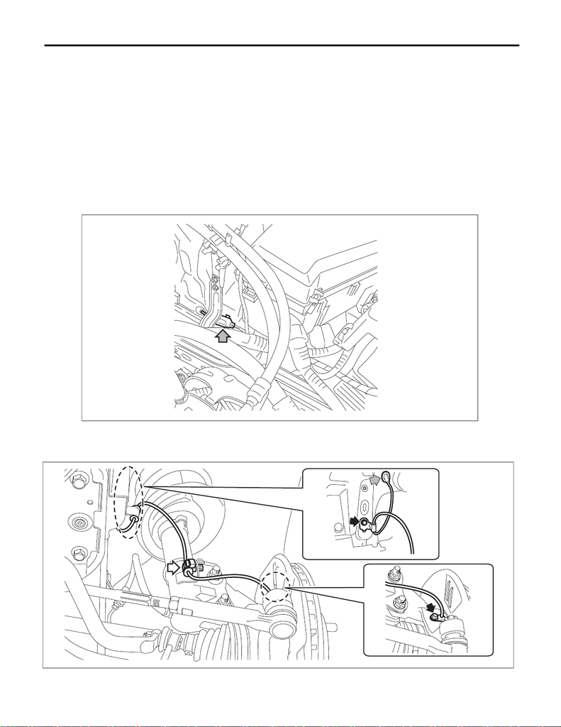

VDC-28

Front ABS Wheel Speed Sensor

VEHICLE DYNAMICS CONTROL (VDC)

9. Front ABS Wheel Speed Sensor

A: REMOVAL

1) Disconnect the ground cable from battery. <Ref. to NT-5, BATTERY, NOTE, Note.>

NOTE:

For models other than STI model, disconnect the ground terminal from battery sensor.

2) Lift up the vehicle, and then remove the front wheels.

3) Remove the front ABS wheel speed sensor.

CAUTION:

• Be careful not to damage the sensor.

• Do not apply excessive force to the sensor harness.

• Leave the sensor harness clamp on the vehicle side.

(1) Disconnect the connector of the front ABS wheel speed sensor in the engine compartment.

(2) Remove each harness clip and grommet.

(3) Remove the bolts, and remove the front ABS wheel speed sensor from the housing assembly - front

axle.

VDC00871

VDC00939

[figure not shown]

VDC-29

Front ABS Wheel Speed Sensor

VEHICLE DYNAMICS CONTROL (VDC)

B: INSTALLATION

CAUTION:

• Be careful not to damage the sensor.

• Do not apply excessive force to the sensor harness.

1) Install the front ABS wheel speed sensor.

Tightening torque:

Front ABS wheel speed sensor: 7.5 N·m (0.8 kgf-m, 5.5 ft-lb)

Front ABS wheel speed sensor bracket: 33 N·m (3.36 kgf-m, 24.3 ft-lb)

2) Install the front wheels.

Tightening torque:

Front wheel: 120 N·m (12.2 kgf-m, 88.5 ft-lb)

3) Lower the vehicle.

NOTE:

Check if the harness is not pulled and does not come in contact with the suspension or body while operating

the steering.

4) Connect the battery ground terminal. <Ref. to NT-5, BATTERY, NOTE, Note.>

NOTE:

For models other than STI model, connect the ground terminal to battery sensor.

C: INSPECTION

1. CHECK WITH SUBARU SELECT MONITOR

1) Connect the Subaru Select Monitor to data link connector.

(1) Run the “PC application for Subaru Select Monitor”.

(2) On «Main Menu» display, select {Each System Check}.

(3) Select {Brake Control System}. When {VDC} is displayed, select the [OK] button.

(4) From {Current Data Display & Save}, select {FR Wheel Speed} and {FL Wheel Speed}.

2) Check if the speed indicated on the display changes in the same manner as the speedometer reading dur-

ing acceleration/deceleration when the steering wheel is in the straight-ahead position.

3) If the speed indicated on the display does not change in the inspection, check the ABS wheel speed sen-

sor. <Ref. to VDC-30, CHECK ABS WHEEL SPEED SENSOR UNIT, INSPECTION, Front ABS Wheel

Speed Sensor.>

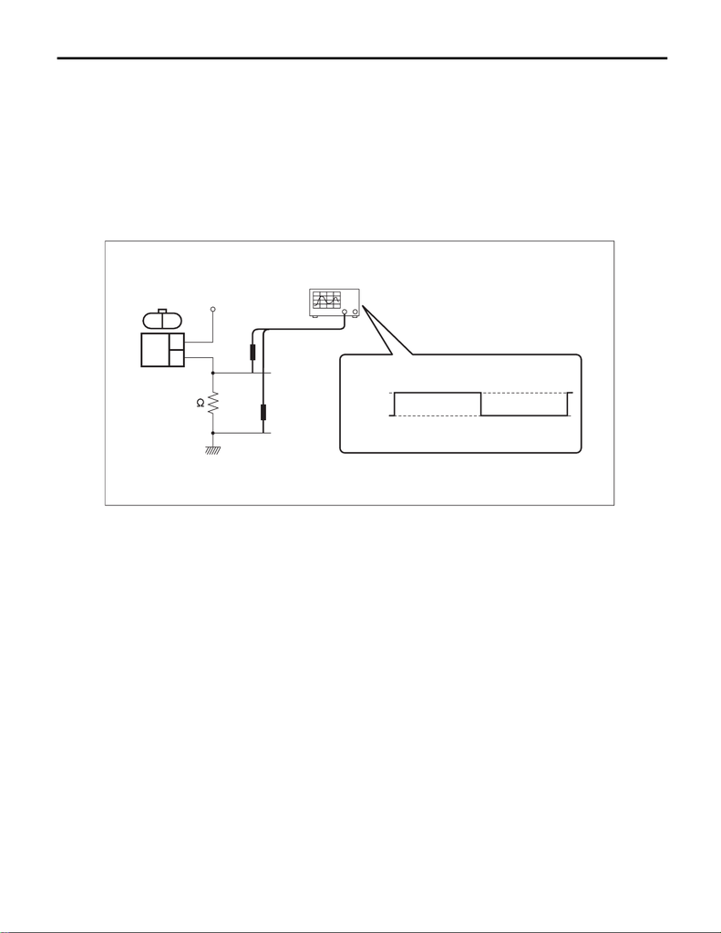

VDC-30

Front ABS Wheel Speed Sensor

VEHICLE DYNAMICS CONTROL (VDC)

2. CHECK ABS WHEEL SPEED SENSOR UNIT

1) Visually check the tip of the ABS wheel speed sensor for foreign particles or damage. If necessary, clean

the tip or replace the ABS wheel speed sensor.

2) Disconnect the ABS wheel speed sensor connector.

3) Check the ABS wheel speed sensor cable for discontinuity. If defective, replace the ABS wheel speed sen-

sor.

oscilloscope.

Standard value of output voltage:

0.7 — 1.4 V

5) Replace the ABS wheel speed sensor if the inspection result is not within the standard value.

VDC00874

100

1.4 V

0.7 V

12 V

1

2

12